# Data Analytics Visualization

DA5020 / Practicum I

Larkin, Yvonne

Sp 2025, February 18th

## Part A: Configuring the Analytics Notebook

Load pharma-sales-randomized.tsv to tibble named *df.pharmaSales* for easier manipulation using dplyr package instead of base R dataframe.

I also loaded all packages needed to knit this file and programmed to install if a package was missing. This was adapted from [6.100 Beginning R: Installing Packages](http://artificium.us/lessons/06.r/l-6-100-beginning-r/l-6-100.html#Installing_Packages) notes.

All code chunks are echoed for this assignment but I have suppressed warnings and messages.

```r
packages <- c("knitr", "kableExtra", "lubridate", "tidyverse")
for(i in 1:length(packages)){
  if(packages[i] %in% rownames (installed.packages()) == FALSE){
    install.packages(packages[i])
  }
}
# I read the library{base} for "? require()" in help tab of RStudio
for(i in 1:length(packages)){
  require(packages[i], character.only = TRUE, warn.conflicts = FALSE, quietly = TRUE)
}
#create tibble of tsv file
#assigned type to each column, n(number) preserved the data entries while excluding $ but dates varied too much to use anything other than c(character) assignment
# read R documentation on read_tsv() for argument handling
df.pharmaSales <- read_tsv("https://s3.us-east-2.amazonaws.com/artificium.us/datasets/pharma-sales-randomized.tsv", col_types = list("c", "n", "n"))

print(head(df.pharmaSales, 4))
```

```
## # A tibble: 4 × 3
##   date        revenue expenses
##   <chr>         <dbl>    <dbl>
## 1 June 1 2022    27.4     23.1
## 2 Apr-04-2023    26.0     23.7
## 3 Jan 2 2022     28.2     23.4
## 4 Apr 5 2022     25.2     23.5
```

## Part B: Preparing and Shaping the Data

For preparing and shaping the data RStudio’s Help tab provided a lot of literature on the functions and their parameter options. I wrote code chunks separately for each subsection of Part B.

### Section I: Detect and Manage Outliers

The notes on [3.203 Detecting and Managing Outliers](http://artificium.us/lessons/03.ml/l-3-203-outliers/l-3-203.html) was very helpful to approach this problem. I defined an outlier as a data point that is more than **3 standard deviations** away from the sample’s respective category mean (revenue or expenses).

```r
#APA citation for code chunk of notes on how to handle outliers: Schedlbauer, M. (2024, June 4). Implementation in R. 3.203 Detecting and Managing Outliers. http://artificium.us/lessons/03.ml/l-3-203-outliers/l-3-203.html
#outlier is a data point more than 3sd from the mean
# revenue outliers
rev.mean <- mean(df.pharmaSales$revenue, na.rm = TRUE) #remove NA values
rev.sd <- sd(df.pharmaSales$revenue, na.rm = TRUE)
#calculate z-score for revenue
z.Rev <- abs((df.pharmaSales$revenue - rev.mean)/rev.sd)
# identify row numbers for revenue outliers
rev.outliers <- which(z.Rev > 3)
# expenses outliers
exp.mean <- mean(df.pharmaSales$expenses, na.rm = TRUE) #remove NA values
exp.sd <- sd(df.pharmaSales$expenses, na.rm = TRUE)
#calculate z-score for expenses
z.Exp <- abs((df.pharmaSales$expenses - exp.mean)/exp.sd)
# identify row numbers for expenses outliers
exp.outliers <- which(z.Exp > 3)
print(paste0("Number of Revenue Outliers: ", length(rev.outliers), " Number of Expenses Outliers: ", length(exp.outliers)))
```

```
## [1] "Number of Revenue Outliers: 0 Number of Expenses Outliers: 1"
```

Ultimately, I am choosing to treat my outliers and (most) missing values in the same way, by replacing them with a value calculated using the mean of all known **sets’** difference in *revenue* and *expenses*.

In order to prepare for that and simplify my code later, I replaced all outliers with *NA_real_* value.

```r
# replace outlier value with NA, reworked from loop
#APA citation: OpenAI. (2025r, February 17). For loop to dplyr. ChatGPT. https://chatgpt.com/c/67b43c10-6268-8006-82f6-3ecb21f6d95e
df.pharmaSales <- df.pharmaSales %>%
  mutate(
    revenue = if_else(row_number() %in% rev.outliers, NA_real_, revenue),
    expenses = if_else(row_number() %in% exp.outliers, NA_real_, expenses)
      )
```

### Section II: Identify and Manage Missing Values

I chose to replace NA values of incomplete sets where either the *revenue* or the *expenses* was known because this data set is small. I need to stick close to the average generated, after excluding outliers, so that I am not skewing the data towards one end or another. Additionally this file only has one data point corresponding to each month across time. Excluding a data point because of an incomplete set would lead to greater jumps between the monthly average projection and differences. I only chose the delete data points where both the *revenue* and the *expenses* data were missing (though there were none in this tsv file). Below I calculate the missing data’s estimated value by either *adding* the mean difference of known sets to *expenses* or *subtracting* the mean difference of known sets from *revenue*.

```r
# needed help converting loops to dplyr functions correctly
#APA citation: OpenAI. (2025p, February 17). dplyr filter row exclusion. ChatGPT. https://chatgpt.com/share/67b55c3e-5998-8006-884c-8963a8bb15ea
filtered.df <- df.pharmaSales %>%
  filter(!(row_number() %in% exp.outliers | row_number() %in% rev.outliers))

filtered.df <- filtered.df %>%
  mutate(difference = revenue - expenses)

#excludes outliers in section I
mean.difference <- mean(filtered.df$difference, na.rm = TRUE)
sd.difference <- sd(filtered.df$difference, na.rm = TRUE)
z.score.difference <- abs((filtered.df$difference - mean.difference)/ sd.difference)

#index row that are outliers according to new 2.5 cutoff
differences.outliers <- which(z.score.difference > 2.5)

#new filtered.df excluding outliers found in section I and II(above)
filtered.df.new <- filtered.df %>%
  filter(!row_number() %in% differences.outliers)

mean.difference.used <- mean(filtered.df.new$difference, na.rm = TRUE)

#replace all missing values, as long as there is either an expense or revenue value
#APA citation: OpenAi. (2025, February 17). dplyr NA replacement. ChatGPT. https://chatgpt.com/share/67b55cbb-f618-8006-a5c6-1b24d1e9e509
# decided to create a tibble of excluded values to preserve for future reference if needed (in this case there are no dates where both values are NA)
excludedSales <- df.pharmaSales %>%
  filter(is.na(expenses) & is.na(revenue))

df.pharmaSales <- df.pharmaSales %>%
  filter(
    #filter out any datasets that have neither value
    !(is.na(expenses) & is.na(revenue))
    ) %>%
  mutate(
    #assign new data value to any previously incomplete sets
    expenses = ifelse(is.na(expenses), revenue - round(mean.difference.used, 2), expenses),
    revenue = ifelse(is.na(revenue), expenses + round(mean.difference.used, 2), revenue)
  )
```

Because we are not only looking at the overall trend but also making projections, I chose to be more conservative in my *mean difference* value by using a standard deviation cutoff of 2.5 for outlier detection. In this case 2 outliers were removed before calculating the mean difference = 3.4809375.

### Section III: Split Date into Three Columns

Notes on [6.113 Working with Date and Time Values in R](http://artificium.us/lessons/06.r/l-6-113-date-time-in-r/l-6-113.html#Parsing_Date_Strings) was very helpful to address this section. I also read RStudio’s Help tab on lubridate package, functions, and parameters to approach date and time problems in this assignment.

```r
#APA citation: Schedlbauer, M. (2024b, January 24). The lubridate Package. 6.113 Working with Date and Time Values in R. http://artificium.us/lessons/06.r/l-6-113-date-time-in-r/l-6-113.html
#Parsing_Date_Strings
df.pharmaSales <- df.pharmaSales %>%
  mutate(
    date = mdy(date),
    month = month(date, label = TRUE, abbr = FALSE),
    day = day(date),
    year = year(date)
  )
print(head(df.pharmaSales, 4))
```

```
## # A tibble: 4 × 6
##   date       revenue expenses month     day  year
##   <date>       <dbl>    <dbl> <ord>   <int> <dbl>
## 1 2022-06-01    27.4     23.1 June        1  2022
## 2 2023-04-04    26.0     23.7 April       4  2023
## 3 2022-01-02    28.2     23.4 January     2  2022
## 4 2022-04-05    25.2     23.5 April       5  2022
```

```r
# the context I used to account for NA values in partII
#add as column to current data frame
df.pharmaSales <- df.pharmaSales %>%
  mutate(
    ProfitLoss = (revenue - expenses) * 1000
  )
print(head(df.pharmaSales, 4))
```

```
## # A tibble: 4 × 7
##   date       revenue expenses month     day  year ProfitLoss
##   <date>       <dbl>    <dbl> <ord>   <int> <dbl>      <dbl>
## 1 2022-06-01    27.4     23.1 June        1  2022      4330
## 2 2023-04-04    26.0     23.7 April       4  2023      2380
## 3 2022-01-02    28.2     23.4 January     2  2022      4860
## 4 2022-04-05    25.2     23.5 April       5  2022      1710.
```

## Part C : Aggregating Data in Tables

This section also has the code blocks divided by section to create each Table display. Notes from [Data Manipulation with dplyr](http://artificium.us/lessons/06.r/l-6-107-dplyr/l-6-107.html#Prequisites) was very helpful for this entire part as I am more used to loop logic and had to work a lot to implement dplyr logic instead, I have the sections of AI help on converting the logic more accurately cited in blocks.

### Section I: Table for Quarterly Revenue Per Year

There were no “quarters” defined in the Practicum. I know it can vary depending on the company or need, where finances often have the fiscal year begin in August. However for the purposes of this assignment I defined my quarters at the start of the Gregorian calendar with the month January.

```r
# define quarters
Q1 <- c("January", "February", "March")
Q2 <- c("April", "May", "June")
Q3 <- c("July", "August", "September")
Q4 <- c("October", "November", "December")

# make column to group by quarter
#APA citation: OpenAI. (2025r, February 17). Group by Year Quarter. ChatGPT. https://chatgpt.com/share/67b55ced-3e5c-8006-8941-67e4d5fcd29c
df.pharmaSales <- df.pharmaSales %>%
  mutate(
    quarter = case_when(
      month %in% Q1 ~ "Q1",
      month %in% Q2 ~ "Q2",
      month %in% Q3 ~ "Q3",
      month %in% Q4 ~ "Q4",
      TRUE ~ NA_character_
    )
  )

#group table by quarter and year (where I use quarter first, so the years are visually easy to compare)
rev_table <- df.pharmaSales %>%
  group_by(quarter, year) %>%
  summarize(total_revenue = sum(revenue) * 1000, .groups = "keep") %>%
  mutate(
    total_revenue = format(total_revenue, big.mark = ",", scientific = FALSE),
    total_revenue = paste0("$", total_revenue)
    ) %>%
  rename(
    `Quarter` = quarter,
    `Year` = year,
    `Total Revenue` = total_revenue
  )

#APA citation: Yihui Xie, C. D. (2024, September 17). R markdown cookbook. 10.2 The kableExtra package. https://bookdown.org/yihui/rmarkdown-cookbook/kableextra.html
#collapse by quarter
rev_table <- rev_table %>%
  kable(
    caption = "Revenue total by Quarter Each Year",
    align = 'ccr',
    format = "html"
  ) %>%
  kable_styling(full_width = TRUE) %>%
  collapse_rows(columns = 1, valign = "middle")

rev_table
```

Revenue total by Quarter Each Year

| Quarter | Year | Total Revenue |
| --- | --- | --- |
| Q1 | 2022 | $81,040 |
|  | 2023 | $80,090 |
|  | 2024 | $72,370 |
| Q2 | 2022 | $78,810 |
|  | 2023 | $77,300 |
|  | 2024 | $79,340 |
| Q3 | 2022 | $86,980 |
|  | 2023 | $81,920 |
|  | 2024 | $77,980 |
| Q4 | 2022 | $91,140 |
|  | 2023 | $84,120 |
|  | 2024 | $76,770 |

### Section II: Table of Revenue, Expenses, and Profit-Loss Per Month averaged across Years

Group data to have average of all values for a given category in a specific month regardless of corresponding year.

```r
# group by month and average all values
avg_per_month_table <- df.pharmaSales %>%
  group_by(month) %>%
  summarize(avg_rev = mean(revenue) * 1000,
            avg_exp = mean(expenses) *1000,
            avg_loss = round(mean(ProfitLoss), 2)) %>%
  mutate(
    #add commas for thousands and $
    avg_rev = format(avg_rev, big.mark = ",", scientifci = FALSE),
    avg_rev = paste0("$", avg_rev),
    avg_exp = format(avg_exp, big.mark = ",", scientifci = FALSE),
    avg_exp = paste0("$", avg_exp),
    avg_loss = format(avg_loss, big.mark = ",", scientifci = FALSE),
    avg_loss = paste0("$", avg_loss),
  ) %>%
  rename(
    #make nicer for table display
    `Average Revenue` = avg_rev,
    `Average Expenses` = avg_exp,
    `Average Profit Loss` = avg_loss,
    `Month` = month
  )

avg_per_month_table <- avg_per_month_table %>%
  kable(
    caption = "Averages by Month across all Years",
    align = 'lccc',
    format = "html"
  ) %>%
  kable_styling(full_width = TRUE) %>%
  column_spec(1, column = )

avg_per_month_table
```

Averages by Month across all Years

| Month | Average Revenue | Average Expenses | Average Profit Loss |
| --- | --- | --- | --- |
| January | $26,230.00 | $22,616.67 | $3,613.33 |
| February | $26,180.00 | $22,913.33 | $3,266.67 |
| March | $25,423.33 | $23,130.00 | $2,293.33 |
| April | $25,493.33 | $22,970.00 | $2,523.33 |
| May | $26,063.33 | $23,743.33 | $2,320.00 |
| June | $26,926.67 | $23,523.33 | $3,403.33 |
| July | $27,260.00 | $23,053.33 | $4,206.67 |
| August | $27,113.33 | $23,140.00 | $3,973.33 |
| September | $27,920.00 | $23,810.00 | $4,110.00 |
| October | $27,890.00 | $23,296.67 | $4,593.33 |
| November | $28,020.00 | $22,570.00 | $5,450.00 |
| December | $28,100.00 | $21,916.67 | $6,183.33 |

### Section III: Percentage Change in Revenue, Expenses, and Profit-Loss from the Prior Month

$$\text{% Change in X} =
\frac{\text{Current Month's Value X} - \text{Previous Month's
Value X}}{\text{Previous Month's Value X}} \times 100$$
where X is the category: revenue, expenses, or profit-loss

```r
#APA citation: OpenAI. (2025s, February 17). Percent Change dplyr instead of loop. ChatGPT. https://chatgpt.com/share/67b55d27-b914-8006-9890-e64bb3d8cf02
percent_change_table <- df.pharmaSales %>%
  arrange(year, date) %>%
  mutate(
    #calculate percent change from previous month
    perc_revChange = round(((revenue - lag(revenue)) / lag(revenue)) * 100, 2),
    perc_expChange = round(((expenses - lag(expenses)) / lag(expenses)) * 100, 2),
    perc_lossChange = round(((ProfitLoss - lag(ProfitLoss))/ lag(ProfitLoss)) * 100, 2)
  ) %>%
  rename(
    #format nicer for table, but still currently a tibble
    `% Change of Revenue` = perc_revChange,
    `% Change of Expenses` = perc_expChange,
    `% Change of Profit Loss` = perc_lossChange,
    `Month` = month,
    `Year` = year
  )

#make table from tibble
percent_change_table <- percent_change_table[,c(4,6,9:11)] %>%
  kable(
    caption = "Percent Change of Current Month from Previous Month",
    align = 'lcccc',
    format = "html"
  ) %>%
  kable_styling(full_width = TRUE)

percent_change_table
```

Percent Change of Current Month from Previous Month

| Month | Year | % Change of Revenue | % Change of Expenses | % Change of Profit Loss |
| --- | --- | --- | --- | --- |
| January | 2022 | NA | NA | NA |
| February | 2022 | -3.86 | -1.75 | -13.99 |
| March | 2022 | -5.42 | 0.26 | -36.60 |
| April | 2022 | -1.75 | 2.13 | -35.47 |
| May | 2022 | 3.81 | 1.06 | 41.52 |
| June | 2022 | 4.70 | -2.86 | 78.93 |
| July | 2022 | 4.78 | 1.13 | 24.25 |
| August | 2022 | -1.25 | -2.10 | 2.42 |
| September | 2022 | 5.43 | -2.71 | 39.20 |
| October | 2022 | -0.03 | -1.35 | 3.78 |
| November | 2022 | 3.08 | -3.92 | 22.36 |
| December | 2022 | -1.20 | -1.66 | -0.21 |
| January | 2023 | -11.43 | 6.52 | -49.69 |
| February | 2023 | 1.11 | 1.86 | -2.25 |
| March | 2023 | -5.10 | -0.31 | -27.62 |
| April | 2023 | 0.62 | 5.53 | -31.21 |
| May | 2023 | -2.92 | 2.54 | -57.14 |
| June | 2023 | 2.89 | -0.12 | 74.51 |
| July | 2023 | 2.81 | -0.50 | 47.75 |
| August | 2023 | -0.07 | 3.40 | -31.94 |
| September | 2023 | 6.63 | 4.94 | 30.17 |
| October | 2023 | -0.32 | -4.74 | 49.36 |
| November | 2023 | -2.75 | -2.81 | -2.30 |
| December | 2023 | 1.85 | -2.19 | 30.59 |
| January | 2024 | -16.43 | -5.36 | -75.45 |
| February | 2024 | 2.72 | 3.97 | -22.94 |
| March | 2024 | 2.44 | 2.83 | -8.33 |
| April | 2024 | 2.02 | -9.22 | 351.95 |
| May | 2024 | 5.98 | 6.76 | 1.15 |
| June | 2024 | 2.36 | 0.22 | 16.48 |
| July | 2024 | -3.80 | -6.66 | 12.44 |
| August | 2024 | -0.23 | -0.32 | 0.22 |
| September | 2024 | -3.39 | 6.47 | -49.57 |
| October | 2024 | 0.04 | 0.00 | 0.43 |
| November | 2024 | 0.98 | -2.69 | 37.18 |
| December | 2024 | 0.39 | -4.81 | 36.76 |

## Part D : Making a Forecast

Instructions at start of the Practicum say to project the next two months not just one month as stated in this Part D section so I did the 2 month projection but had a really hard time trying to integrate a function made with a loop into the dyplr functionality. Because of that I have a very redundant code chunk to calculate the second month projection.

```r
#WMA (weighted moving average) of prior 3 months with 0.6, 0.3, 0.1 from most recent to older
weights <- c(0.6, 0.3, 0.1)
weighted_average <- df.pharmaSales %>%
  arrange(date) %>%
  # calculate weighted moving average for revenue and expenses
  # change lag to n = 0,1,2 because it is the current month and prior 2 months to project the next month not the prior 3 months to the current to project the next month
  mutate(
    #n values (0 = current month; 1 = previous month; 2 = 2 months back)
    #weighted average revenue calculation
    wt_avg_rev = ifelse(row_number() > 2,
                        lag(revenue, n = 0) * weights[1] + lag(revenue, n = 1) * weights[2] + lag(revenue, n = 2) * weights[3], NA_real_),
    #weighted average expenses calculation
    wt_avg_exp = ifelse(row_number() > 2,
                        lag(expenses, n = 0) * weights[1] + lag(expenses, n = 1) * weights[2] + lag(expenses, n = 2) * weights[3], NA_real_),
    #weighted average ProfitLoss calculation
    wt_avg_PL = ifelse(row_number() > 2,
                       lag(ProfitLoss, n = 0) * weights[1] + lag(ProfitLoss, n = 1) * weights[2] + lag(ProfitLoss, n = 2) * weights[3], NA_real_))
#APA citation: OpenAI. (2025u, February 18). Weighted Moving Average R. ChatGPT. https://chatgpt.com/share/67b55d58-773c-8006-8d53-e440fdb7eb9f
#did separately thought I don't know if fully necessary
weighted_average <- weighted_average %>%
    add_row(date = last(weighted_average$date) + months(1),
          revenue = last(weighted_average$wt_avg_rev),
          expenses = last(weighted_average$wt_avg_exp),
          month = month(date, label = TRUE, abbr = FALSE),
          day = day(date),
          year = year(date),
          ProfitLoss = (revenue - expenses) * 1000,
          quarter = case_when(
            month %in% Q1 ~ "Q1",
            month %in% Q2 ~ "Q2",
            month %in% Q3 ~ "Q3",
            month %in% Q4 ~ "Q4",
            TRUE ~ NA_character_))

#I couldn't figure out how to streamline as a function to prevent redundancy in my code
#for the purposes of achieving the 2 month forecast I repeated the code from above
#It's very redundant from here to the bottom of the block, I appologize, I will work on it

#this redoes the WMA calculation for all rows including the newly added one
weighted_average <- weighted_average %>%
  arrange(date) %>%
  mutate(
    wt_avg_rev = ifelse(row_number() > 2,
                        lag(revenue, n = 0) * weights[1] + lag(revenue, n = 1) * weights[2] + lag(revenue, n = 2) * weights[3], NA_real_),
    wt_avg_exp = ifelse(row_number() > 2,
                        lag(expenses, n = 0) * weights[1] + lag(expenses, n = 1) * weights[2] + lag(expenses, n = 2) * weights[3], NA_real_),
    wt_avg_PL = ifelse(row_number() > 2,
                       lag(ProfitLoss, n = 0) * weights[1] + lag(ProfitLoss, n = 1) * weights[2] + lag(ProfitLoss, n = 2) * weights[3], NA_real_))

#this adds a SECOND new row of a projection
weighted_average <- weighted_average %>%
    add_row(date = last(weighted_average$date) + months(1),
          revenue = last(weighted_average$wt_avg_rev),
          expenses = last(weighted_average$wt_avg_exp),
          month = month(date, label = TRUE, abbr = FALSE),
          day = day(date),
          year = year(date),
          ProfitLoss = (revenue - expenses) * 1000,
          quarter = case_when(
            month %in% Q1 ~ "Q1",
            month %in% Q2 ~ "Q2",
            month %in% Q3 ~ "Q3",
            month %in% Q4 ~ "Q4",
            TRUE ~ NA_character_))

#this redoes the WMA calculation for all rows including the newly added one
weighted_average <- weighted_average %>%
  arrange(date) %>%
  mutate(
    wt_avg_rev = ifelse(row_number() > 2,
                        lag(revenue, n = 0) * weights[1] + lag(revenue, n = 1) * weights[2] + lag(revenue, n = 2) * weights[3], NA_real_),
    wt_avg_exp = ifelse(row_number() > 2,
                        lag(expenses, n = 0) * weights[1] + lag(expenses, n = 1) * weights[2] + lag(expenses, n = 2) * weights[3], NA_real_),
    wt_avg_PL = ifelse(row_number() > 2,
                       lag(ProfitLoss, n = 0) * weights[1] + lag(ProfitLoss, n = 1) * weights[2] + lag(ProfitLoss, n = 2) * weights[3], NA_real_))

print(tail(weighted_average, 6))
```

```
## # A tibble: 6 × 11
##   date       revenue expenses month      day  year ProfitLoss quarter wt_avg_rev
##   <date>       <dbl>    <dbl> <ord>    <int> <dbl>      <dbl> <chr>        <dbl>
## 1 2024-09-02    25.4     23.0 Septemb…     2  2024      2330. Q3            25.7
## 2 2024-10-03    25.4     23.0 October      3  2024      2340  Q4            25.5
## 3 2024-11-02    25.6     22.4 November     2  2024      3210  Q4            25.5
## 4 2024-12-01    25.7     21.4 December     1  2024      4390. Q4            25.7
## 5 2025-01-01    25.7     21.8 January      1  2025      3831  Q1            25.7
## 6 2025-02-01    25.7     21.8 February     1  2025      3937. Q1            25.7
## # ℹ 2 more variables: wt_avg_exp <dbl>, wt_avg_PL <dbl>
```

We were told to calculate the next month based on the given weights 0.6, 0.3, 0.1. I printed the last 6 rows of the adjusted tibble, it contains the 2 forecasted months.

## Part E : Building a Visualization

I used ggplot2 package instead of base R for plotting because it has more robust features. However I am very new to it so I needed RStudio help tab, [ggplot “cheatsheet”](https://github.com/rstudio/cheatsheets/blob/main/data-visualization.pdf), and AI assistance to understand how to utilize the function especially for finite adjustments to mimick the example [photo](https://northeastern.instructure.com/courses/206741/files/32748675/preview).

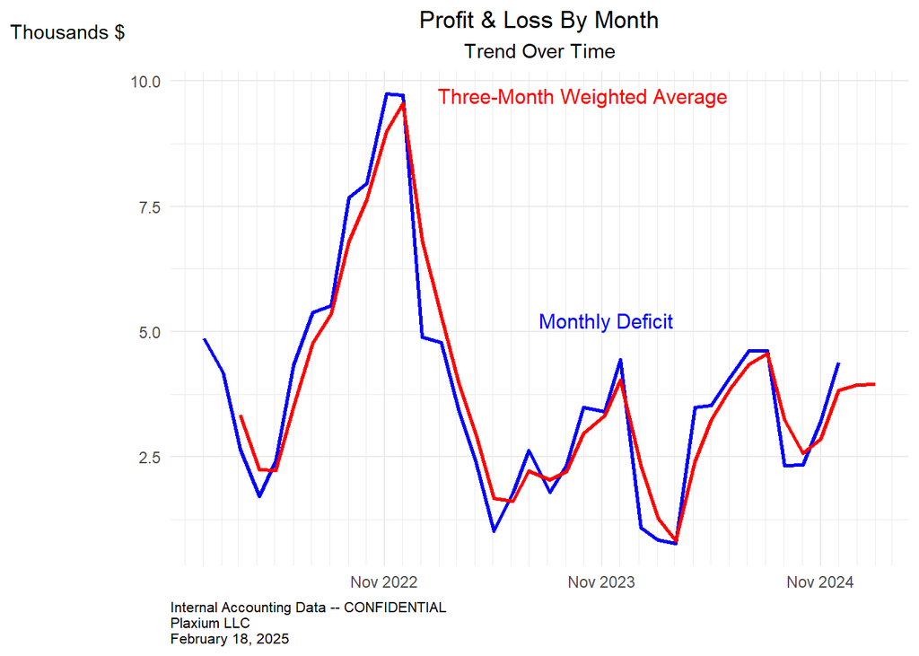

```r
#APA citation: Basyar,  lqbal, & camille. (2019, October 3). Changing Placement & alignment of GGPLOT Legend Labels. Stack Overflow. https://stackoverflow.com/questions/58221686/changing-placement-alignment-of-ggplot-legend-labels
#APA citation: OpenAI. (2025u, February 18). Introduction to ggplot2. ChatGPT. https://chatgpt.com/share/67b5222d-eb40-8006-b230-48148cb9eaf8
weighted_average <- weighted_average %>%
  mutate(filtered_ProfitLoss = ifelse(row_number() > (n() - 2), NA_real_, ProfitLoss))

ggplot(weighted_average, aes(x = date)) +
  # remove the last 2 months because those are projections and not actual monthly deficits
  geom_line(aes(y = filtered_ProfitLoss/1000, color = "Profit Loss"), na.rm = TRUE, size = 1) +
  geom_line(aes(y = wt_avg_PL/1000, na.rm = TRUE, color = "Three-Month Moving Average"), size = 1) +
  annotate("text", x = median(weighted_average$date, na.rm = TRUE), y = median(weighted_average$ProfitLoss/1000, na.rm = TRUE), label = "Monthly Deficit", color = "blue", vjust = -5, hjust = 0, size = 4) +
  #honestly don't fully understand vjust and hjust numeric shifting, I assume 0,0 is point of annotation and +/- operate as an axis, might be inverted?
  #positive hjust goes left and negative goes right
  #negative vjust goes up and positive goes down
  annotate("text", x = median(weighted_average$date, na.rm = TRUE), y = max(weighted_average$wt_avg_PL/1000, na.rm = TRUE), label = "Three-Month Weighted Average", color = "red", vjust = 0, hjust = 0.35, size = 4) +
  labs(x = NULL,
       y = "Thousands $",
       title = "Profit & Loss By Month",
       subtitle = "Trend Over Time",
       caption = "Internal Accounting Data -- CONFIDENTIAL\nPlaxium LLC\nFebruary 18, 2025"
       ) +
  scale_x_date(date_breaks = "12 months",
               date_labels = "%b %Y",
               minor_breaks = "1 month",
               limits = c(min(weighted_average$date, na.rm = TRUE), max(weighted_average$date, na.rm = TRUE))
               ) +
  #kept this for color because without it the colors were a weird pastel version
  scale_color_manual(values = c("Profit Loss" = "blue", "Three-Month Moving Average" = "red")) +
  theme_minimal() +
  theme(
    legend.position = "none", #hide legend
    plot.title = element_text(hjust = 0.5),
    plot.subtitle = element_text(hjust = 0.5),
    plot.caption = element_text(hjust = 0, size = 8), #align left
    axis.title.y = element_text(angle = 0, vjust = 1.1)
  )
```